# Cena pohonných hmot a nově registrovaná auta podle typu paliva

petr.koci@samizdat.cz

února 2015

## Jak se vyvíjela cena benzinu a nafty

Český statistický úřad má ceny paliv k dispozici [až roku 2009](http://www.czso.cz/csu/csu.nsf/kalendar/aktual-tdb). Dostatečně dlouhou časovou řadu jsme [našli u CCS](http://www.ccs.cz/pages/phm2.php), která ovšem nesleduje ceny LPG ani dalších alternativních paliv. Pokud byste věděli o zdroji takových dat, můžeme je doplnit.

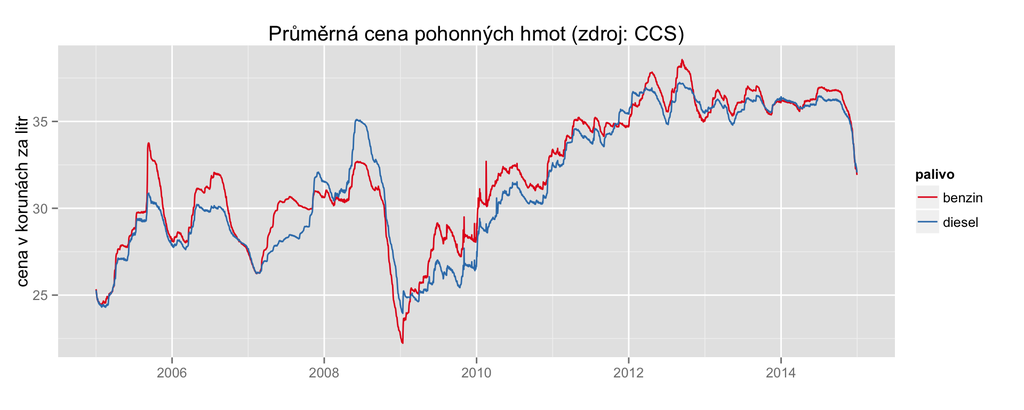

## Jak se vyvíjela cena benzinu a nafty - interaktivní verze

[interactive chart not shown]

Na vlastní web si můžete graf vložit pomocí následujícího kódu.

```
<iframe src = "https://samizdat.cz/data/diesely/www/#ceny" width = "610" height = "240" frameborder = "0" scrollling = "0"></iframe>
```

## Kolik pohonných hmot jste si mohli koupit za průměrný plat - interaktivní verze

[interactive chart not shown]

Na vlastní web si můžete graf vložit pomocí následujícího kódu.

```
<iframe src = "https://samizdat.cz/data/diesely/www/#prummzda" width = "610" height = "240" frameborder = "0" scrollling = "0"></iframe>
```

## Nově registrovaná auta podle pohonu

Údaje o nově registrovaných osobních autech máme od [Svazu dovozců automobilů](http://portal.sda-cia.cz/stat.php?n#str=nova). Zahrnují i tuzemské výrobce a jiné nečleny, měly by odrážet celkovou situaci na trhu.

Výrazný je nástup dieselů v roce 2009, který koresponduje se začátkem dlouhodobého zdražování pohonných hmot, benzinu i nafty. Sezónní výkyvy v prodejích jsou nejspíš známá věc: nejvíc nových aut se prodává na jaře a před koncem roku, nejméně v lednu.

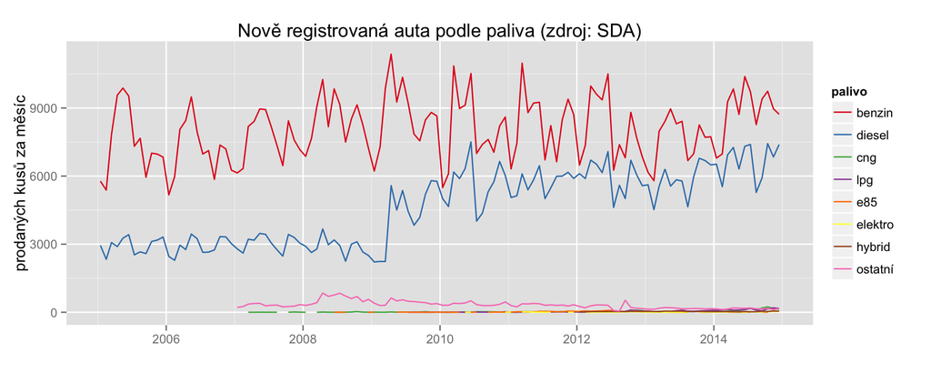

## Rozdělení trhu s novými auty

Diesely se dotáhly na benzinová auta, ale jak je vidět z předchozího grafu, v měsíčních prodejích je ještě nikdy nepřekonaly. Alternativní pohony tvoří méně než dvě procenta trhu.

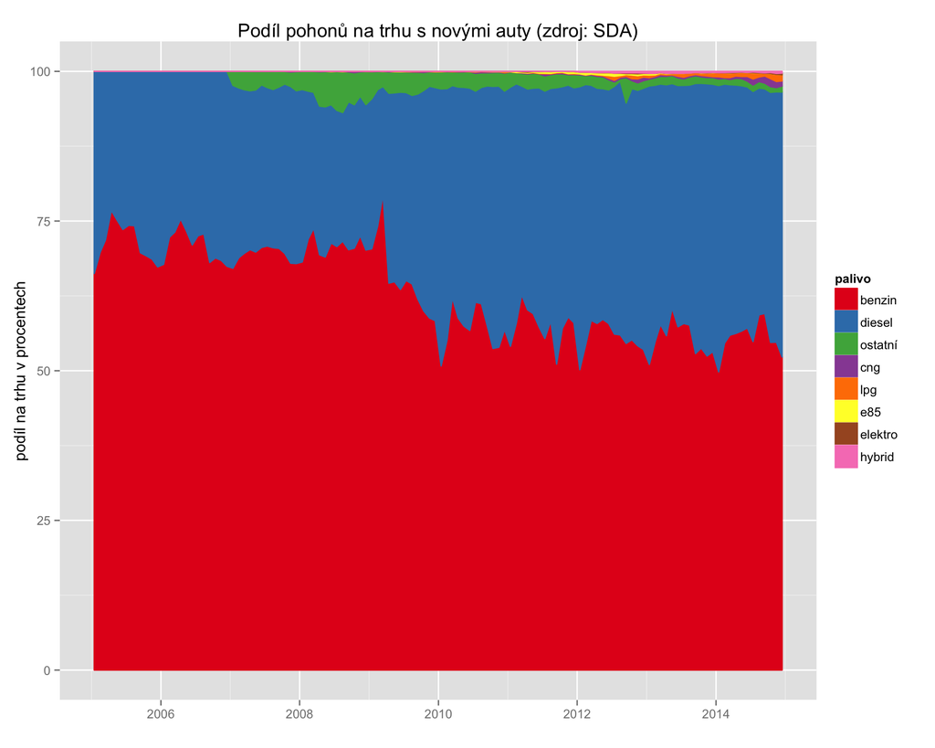

Jak jsme se dozvěděli od SDA, kategorie “ostatní” znamená spíš “nezjištěno”. Můžeme tedy předpokládat, že pohony v ní jsou rozdělené přibližně stejně jako na celém trhu a z grafu ji odstranit:

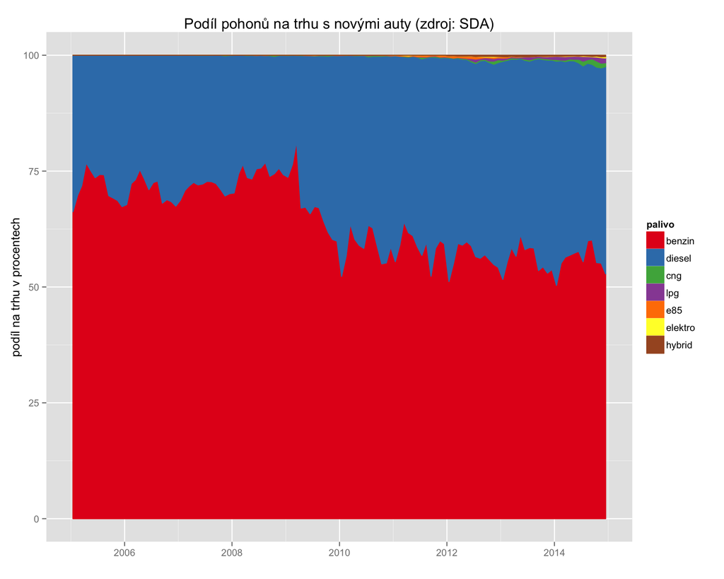

## Prodané kusy aut po letech

Nově registrovaná auta podle pohonu

| rok | benzin | diesel | cng | lpg | e85 | elektro | hybrid | ostatní | celkem |
| --- | --- | --- | --- | --- | --- | --- | --- | --- | --- |
| 2005 | 89701 | 35320 | 0 | 0 | 0 | 0 | 0 | 0 | 125021 |
| 2006 | 85866 | 34873 | 0 | 0 | 0 | 0 | 0 | 0 | 120739 |
| 2007 | 92137 | 36759 | 28 | 0 | 0 | 0 | 0 | 3618 | 132542 |
| 2008 | 101686 | 34618 | 67 | 0 | 12 | 0 | 0 | 7278 | 143661 |
| 2009 | 104885 | 51364 | 103 | 19 | 32 | 5 | 0 | 5251 | 161659 |
| 2010 | 96942 | 67681 | 150 | 69 | 32 | 6 | 0 | 4356 | 169236 |
| 2011 | 100152 | 68510 | 194 | 127 | 345 | 56 | 0 | 3898 | 173282 |
| 2012 | 97067 | 72012 | 470 | 514 | 588 | 89 | 362 | 2907 | 174009 |
| 2013 | 91389 | 69746 | 379 | 647 | 106 | 37 | 438 | 1994 | 164736 |
| 2014 | 106786 | 80128 | 1402 | 1481 | 20 | 197 | 386 | 1914 | 192314 |

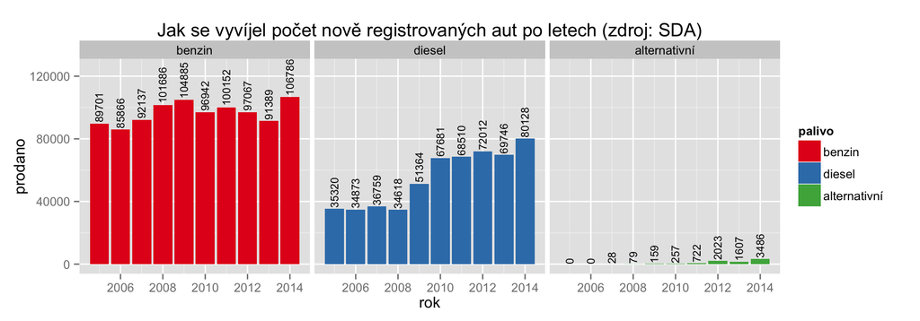

## Detailní pohled na alternativní pohony

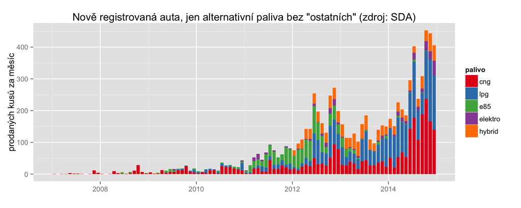

## Detailní pohled na alternativní pohony - interaktivní verze

Při najetí myši nad sloupeček se zobrazí podrobnosti. Kliknutím na název kategorie pod grafem si můžete přidávat, ubírat a porovnávat různá paliva.

[interactive chart not shown]

Na vlastní web si můžete graf vložit pomocí následujícího kódu.

```
<iframe src = "https://samizdat.cz/data/diesely/www/#e85,cng,lpg" width = "610" height = "320" frameborder = "0" scrolling = "no"></iframe>
```

V první části si můžete nastavit, která paliva se zobrazí při prvním načtení grafu. Pokud tedy píšete článek o e85 a chcete ukázat především prodeje těchto aut, smažete “,cng,lpg” a první parametr bude jen src=“https://samizdat.cz/data/diesely/www/#e85”.

## Jak přibývalo řepky olejky

Může to být zajímavé hlavně v souvislosti s dotacemi na bioethanol.

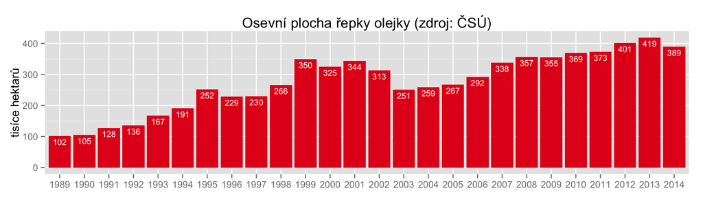